# R에서 남한지도 그려보기

김병건

2019 9 7

# 필요한 패키지 설치

# 남한지도를 그려보겠습니다.

동(또는 면/리)단위로 구역이 나뉘어진 지도입니다.

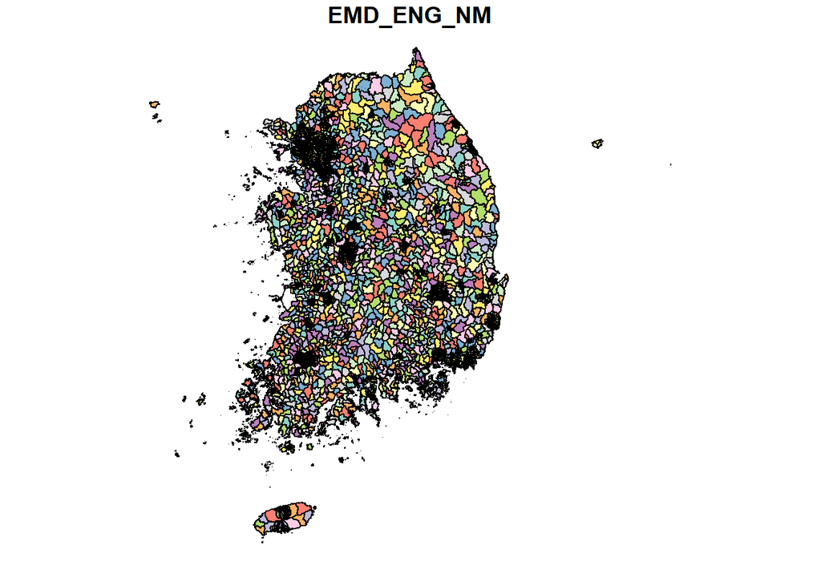

# 지도를 그리기 위해서 알아야할 내용들

지도를 그리기 위해서는 우선, 지도를 구성하고 있는 데이터에 대해서 알아야 합니다.

- 지도 데이터, shape file 에 대한 설명은 아래를 링크를 참고하세요.
- https://endofcap.tistory.com/3
- http://www.snpo.kr/data//file/meetshare_epilogue/2949849334_CGywx7W5_slide3.pdf

shape file만 올바르게 작성되어 있다면, 위에서 보신 것 과 같이 쉽게 지도를 그릴 수 있씁니다.

- shape file 다운 받은 곳
- http://www.gisdeveloper.co.kr/?p=2332&unapproved=28711&moderation-hash=bf738becd6dd0f8b10fd61503ceb93e7#comment-28711

## 지도 데이터(shape file)의 기본구조

EMD_CD : 법정동 코드의 시/도 + 군/구 + 동 코드입니다. * 법정동 코드는 아래 링크 참고하세요. * https://financedata.github.io/posts/korea-area-code.html

EMD_ENG_NM : 동 영문 표기 EMD_KOR_NM : 동 한글 표기 (cp949로 인코딩 되어 있어서, UTF-8에서 올바르게 표기 되지 않았습니다. 뒤에서 UTF-8으로 변환 하겠습니다.) geometry : 동의 좌표를 가지고 있는 부분입니다.

shape file은 현재 ’Simple feature’라른 이름으로 ISO에서 표준화한 포맷이 되었습니다.

```
## [1] "sf"         "data.frame"
```

| EMD_CD | EMD_ENG_NM | EMD_KOR_NM | geometry |
| --- | --- | --- | --- |
| 11110101 | Cheongun-dong | u |  |
| 11110102 | Singyo-dong |  |  |
| 11110103 | Gungjeong-dong |  |  |
| 11110104 | Hyoja-dong |  |  |
| 11110105 | Changseong-dong | a |  |
| 11110106 | Tongui-dong |  |  |
| 11110107 | Jeokseon-dong |  |  |
| 11110108 | Tongin-dong | ε |  |
| 11110109 | Nusang-dong |  |  |
| 11110110 | Nuha-dong |  |  |

[output cut: 5037 more lines]

## 지도 데이터 클리닝

EMD_KOR_NM 인코딩을 CP949에서 UTF-8로 변경해서, 깨진 한글을 복구합니다.

|  | EMD_CD | EMD_ENG_NM | EMD_KOR_NM | geometry |
| --- | --- | --- | --- | --- |
| 1 | 11110101 | Cheongun-dong | 청운동 |  |
| 2 | 11110102 | Singyo-dong | 신교동 |  |
| 3 | 11110103 | Gungjeong-dong | 궁정동 |  |
| 4 | 11110104 | Hyoja-dong | 효자동 |  |
| 5 | 11110105 | Changseong-dong | 창성동 |  |
| 6 | 11110106 | Tongui-dong | 통의동 |  |

# 지도 데이터를, 데이터프레임으로 변환

shape file의 포맷은 주로 사용해왔던 데이터프레임과 함께 다루기가 어렵기 때문에, shape file을 데이터 프레임으로 변환합니다.

## shape file에서 데이터 프레임으로

shape file의 데이터 dongs_shp에서 geometry컬럼 부분, 즉 spatial 부분만 뽑아 냅니다.

```
## [1] "SpatialPolygonsDataFrame"
## attr(,"package")
## [1] "sp"
```

dongs_seoul_spatial 의 안을 보면, data 와 polygons 둘로 나뉘어 있습니다.

- data 부분이 데이터 프레임으로 법정동코드, 동이름, 을 담고 있고
- polygons는 동의 모습을 폴리곤으로 담고 있습니다.

두 부분을 각각 아래와 같이 변환 합니다.

|  | EMD_CD | EMD_ENG_NM | EMD_KOR_NM |
| --- | --- | --- | --- |
| 1 | 11110101 | Cheongun-dong | 청운동 |
| 2 | 11110102 | Singyo-dong | 신교동 |
| 3 | 11110103 | Gungjeong-dong | 궁정동 |
| 4 | 11110104 | Hyoja-dong | 효자동 |
| 5 | 11110105 | Changseong-dong | 창성동 |
| 6 | 11110106 | Tongui-dong | 통의동 |

|  | long | lat | order | hole | piece | id | group |
| --- | --- | --- | --- | --- | --- | --- | --- |
| 1 | 953700.0 | 1954605 | 1 | FALSE | 1 | 1 | 1.1 |
| 2 | 953693.9 | 1954591 | 2 | FALSE | 1 | 1 | 1.1 |
| 3 | 953690.8 | 1954583 | 3 | FALSE | 1 | 1 | 1.1 |
| 4 | 953689.6 | 1954577 | 4 | FALSE | 1 | 1 | 1.1 |
| 5 | 953687.9 | 1954569 | 5 | FALSE | 1 | 1 | 1.1 |
| 6 | 953682.3 | 1954556 | 6 | FALSE | 1 | 1 | 1.1 |

## 2개의 데이터프레임 클리닝

### dongs_data_df에 id 컬럼을 추가

- dongs_data_df 와 dongs_geometry_df를 연결하여 사용할 때, 필요한 id 컬럼을 만들겠습니다.
- EMD_CD를 charater 로 변경하겠습니다.
- EMD_ENG_NM charater 로 변경하겠습니다.

|  | EMD_CD | EMD_ENG_NM | EMD_KOR_NM | id |
| --- | --- | --- | --- | --- |
| 1 | 11110101 | Cheongun-dong | 청운동 | 1 |
| 2 | 11110102 | Singyo-dong | 신교동 | 2 |
| 3 | 11110103 | Gungjeong-dong | 궁정동 | 3 |
| 4 | 11110104 | Hyoja-dong | 효자동 | 4 |
| 5 | 11110105 | Changseong-dong | 창성동 | 5 |
| 6 | 11110106 | Tongui-dong | 통의동 | 6 |

### 법정동 코드 8자리에서 10자리로 변경

EMD_CD컬럼이 법정동 코드를 의미합니다. 법정동 코드는 총 10자리로 구성된 숫자이며, 아래와 같이 조합합니다.

“시/도” + “시/군/구” + “읍/면/동” + “리”

EMD_CD컬럼은 읍/면/동 코드까지 가진 8자리로 예상됩니다. 8자리가 맞는지 확인해보고, 뒤에 00을 붙여서, 총 10자리인 법정동 코드로 변경하겠습니다.

```
## [1] 8
```

모두 8자리 이기 때문에, 뒤에 00을 붙여 줍니다.

|  | EMD_CD | EMD_ENG_NM | EMD_KOR_NM | id |
| --- | --- | --- | --- | --- |
| 1 | 1111010100 | Cheongun-dong | 청운동 | 1 |
| 2 | 1111010200 | Singyo-dong | 신교동 | 2 |
| 3 | 1111010300 | Gungjeong-dong | 궁정동 | 3 |
| 4 | 1111010400 | Hyoja-dong | 효자동 | 4 |
| 5 | 1111010500 | Changseong-dong | 창성동 | 5 |
| 6 | 1111010600 | Tongui-dong | 통의동 | 6 |

dongs_geometry_df의 id 컬럼 타입을 숫자형으로 변환합니다.

|  | long | lat | order | hole | piece | id | group |
| --- | --- | --- | --- | --- | --- | --- | --- |
| 1 | 953700.0 | 1954605 | 1 | FALSE | 1 | 1 | 1.1 |
| 2 | 953693.9 | 1954591 | 2 | FALSE | 1 | 1 | 1.1 |
| 3 | 953690.8 | 1954583 | 3 | FALSE | 1 | 1 | 1.1 |
| 4 | 953689.6 | 1954577 | 4 | FALSE | 1 | 1 | 1.1 |
| 5 | 953687.9 | 1954569 | 5 | FALSE | 1 | 1 | 1.1 |
| 6 | 953682.3 | 1954556 | 6 | FALSE | 1 | 1 | 1.1 |

## 2개의 데이터프레임 저장하기

# 지도 그리기

앞에서 shape file에서 데이터를 추출해서, 클리닝을 한 뒤에 csv 파일로 저장하였습니다. CSV파일에서 데이터를 읽어와서, 지도를 그려보겠습니다.

## 동이름, 동 지도 데이터 읽기

factor로 되어 있는것을 character로 변환합니다.

|  | X | EMD_CD | EMD_ENG_NM | EMD_KOR_NM | id |
| --- | --- | --- | --- | --- | --- |
| 1 | 1 | 1111010100 | Cheongun-dong | 청운동 | 1 |
| 2 | 2 | 1111010200 | Singyo-dong | 신교동 | 2 |
| 3 | 3 | 1111010300 | Gungjeong-dong | 궁정동 | 3 |
| 4 | 4 | 1111010400 | Hyoja-dong | 효자동 | 4 |
| 5 | 5 | 1111010500 | Changseong-dong | 창성동 | 5 |
| 6 | 6 | 1111010600 | Tongui-dong | 통의동 | 6 |

|  | X | long | lat | order | hole | piece | id | group |
| --- | --- | --- | --- | --- | --- | --- | --- | --- |
| 1 | 1 | 953700.0 | 1954605 | 1 | FALSE | 1 | 1 | 1.1 |
| 2 | 2 | 953693.9 | 1954591 | 2 | FALSE | 1 | 1 | 1.1 |
| 3 | 3 | 953690.8 | 1954583 | 3 | FALSE | 1 | 1 | 1.1 |
| 4 | 4 | 953689.6 | 1954577 | 4 | FALSE | 1 | 1 | 1.1 |
| 5 | 5 | 953687.9 | 1954569 | 5 | FALSE | 1 | 1 | 1.1 |
| 6 | 6 | 953682.3 | 1954556 | 6 | FALSE | 1 | 1 | 1.1 |

## 첫 지도 그리기

동별로 나뉘어진 첫 지도 그리기 :-)

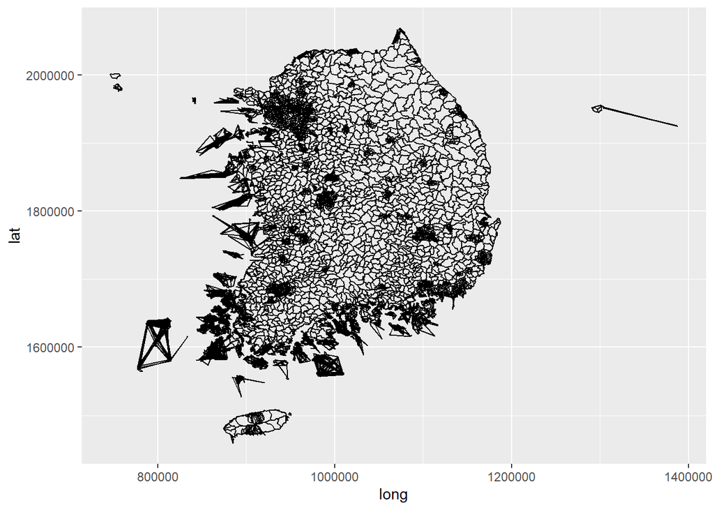

### 좀더 예쁜 지도로

- 지도의 삐쭉 나온 선들은 가려지지가 않네요 -_-;
- 동별로 색도 칠해 봅니다. geom_polygon 의 aes(fill = id)
- 가로/세로 비율이 같은 지도를 그리기 coord_fixed(1)

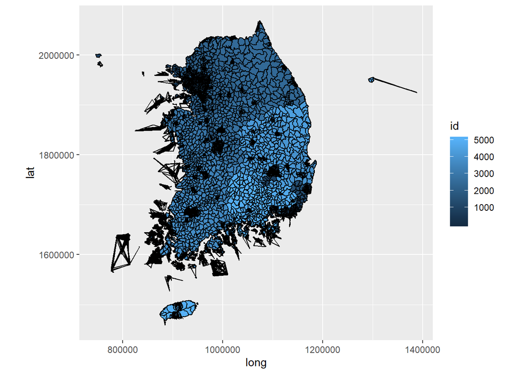

### 서울/종로구 데이터만 뽑아서 사용하겠습니다. (전국 데이터는 너무 커서)

데이터를 뽑기 위해서, 2개의 데이터프레임을 합치고, 법정동 코드에서, 서울/종로구 데이터만 필터합니다.

|  | id | X.x | EMD_CD | EMD_ENG_NM | EMD_KOR_NM | X.y | long | lat | order | hole | piece | group |
| --- | --- | --- | --- | --- | --- | --- | --- | --- | --- | --- | --- | --- |
| 1 | 1 | 1 | 1111010100 | Cheongun-dong | 청운동 | 1 | 953700.0 | 1954605 | 1 | FALSE | 1 | 1.1 |
| 2 | 1 | 1 | 1111010100 | Cheongun-dong | 청운동 | 2 | 953693.9 | 1954591 | 2 | FALSE | 1 | 1.1 |
| 3 | 1 | 1 | 1111010100 | Cheongun-dong | 청운동 | 3 | 953690.8 | 1954583 | 3 | FALSE | 1 | 1.1 |
| 4 | 1 | 1 | 1111010100 | Cheongun-dong | 청운동 | 4 | 953689.6 | 1954577 | 4 | FALSE | 1 | 1.1 |
| 5 | 1 | 1 | 1111010100 | Cheongun-dong | 청운동 | 5 | 953687.9 | 1954569 | 5 | FALSE | 1 | 1.1 |
| 6 | 1 | 1 | 1111010100 | Cheongun-dong | 청운동 | 6 | 953682.3 | 1954556 | 6 | FALSE | 1 | 1.1 |

### 서울/종로구 동이름도 함께

id,EMD_KOR_NM 로 group_by를 하면, 각 동,동이름별로 데이터가 그룹이 되고, 동이름을 표시할 위도/경도를, 동의 외곽을 구성하는 점들의 위도/경도의 평균으로 정합니다.

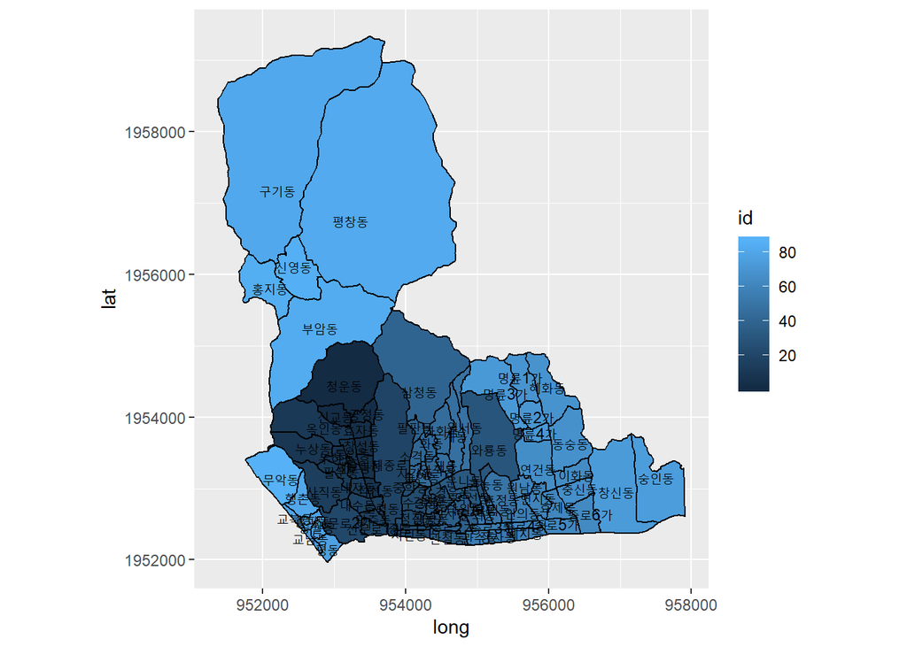

### 보다 큰 크기로 그리기 (작아서 잘 안보임)

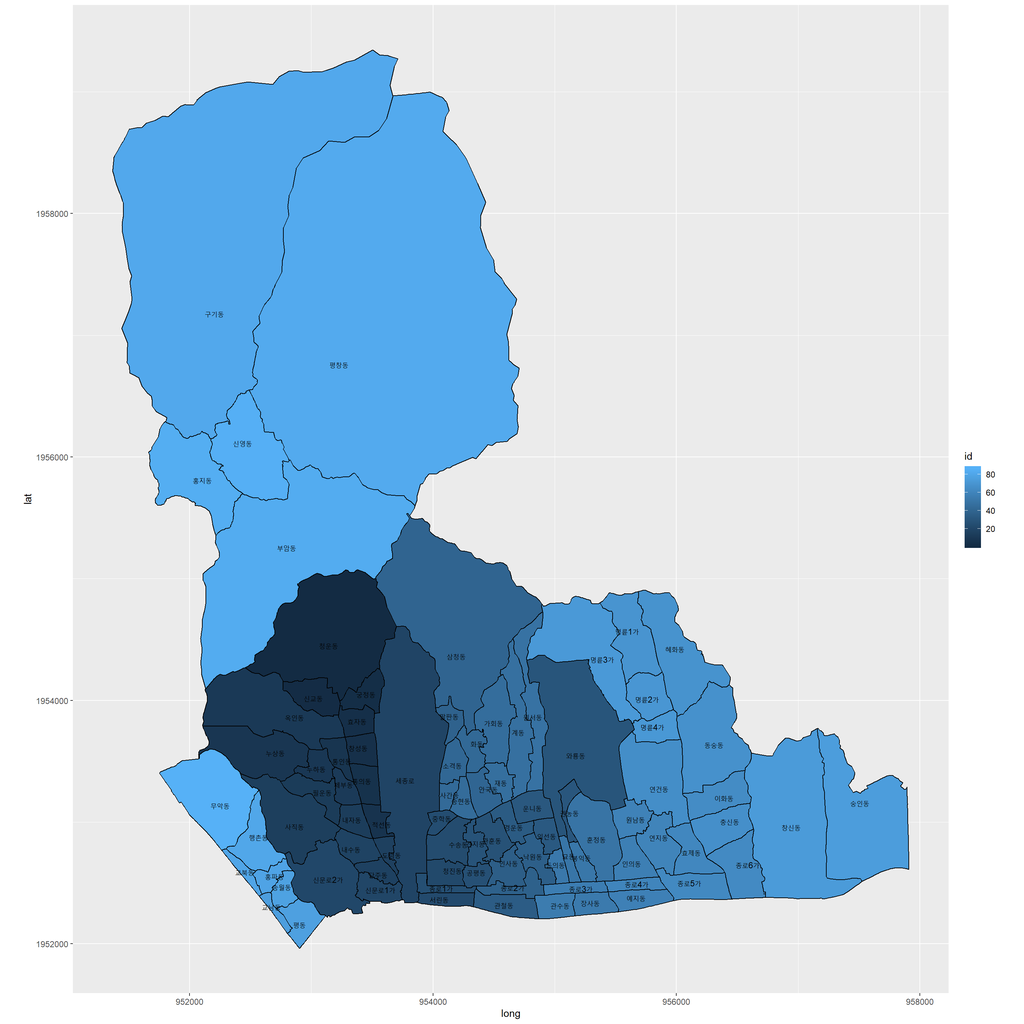

### 동옆에 바차트 그리기

geom_rect()를 사용해서, 지도위에 위도/경도에 해당하는 사각형을 그려서, 바차트 용도로 사용하였습니다.

- geom_subplot() 이 동작안하는 것 같은대, 잘 되시는 분은 연락 주세요 ^^

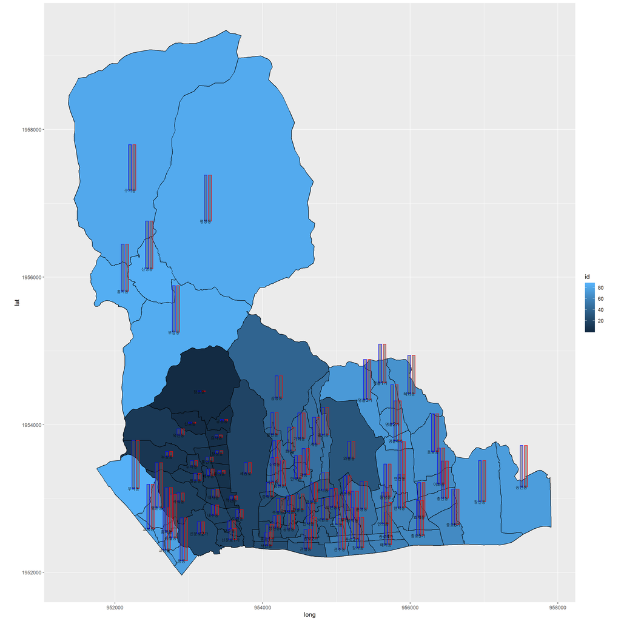

# 마무리 하며

R로 만들어 볼까? 했던 것이 있어서, kormap2014을 사용하면 되겠지… 하면서 시작 했다가, 이런저런 이유로, kormap2014을 사용하기가 어렵게 되면서… 일이 점점 커지다가… 결국은 shape file에서 부터 직접 그리게 되었습니다. :-)

R에서 지도 그리시는 분들에게 도움이 되셨기를 바라며, 이만 마치겠습니다.

김병건 (skysign at_sign gmail.com) 2019년 9월 7일